# Notes 5 - Correlation and Clustering

Jillian Morrison

October 21 2019

# What will we cover

- Correlation
- Unsupervised Learning techniques
  - K means Clustering
  - Hierarchical Chistering

This covers Sections of Chapter 10 of “An Introduction to Statistical Learning” by James, et. al.

# Correlation

**Correlation** is the measure of the strength and direction of the linear relationship between the variables

Direction

- positive relationship is indicated by a positive value (e.g., ranging from 0 to 1)
- negative relationship is indicated by a negative value (e.g., ranging from 0 to -1)

Strength - the farther the value is away from 0, the stronger the relationship.

# Correlation Calculations

For variables $x$ and $y$
$$r_{x,y} = \frac{\sum_{i=1}^n (x_i - \bar{x})(y_i - \bar{y})}{ \sqrt{\sum_{i=1}^n (x_i - \bar{x})^2} \sqrt{\sum_{i=1}^n (y_i - \bar{y})^2}}$$

For example:

```r
> library(dplyr)
> ##Create dataset
> data=data.frame(x=rnorm(1000))
> data=data%>%mutate(y= x+rgamma(1000,2),z=2*x+rnorm(1000))
> head(data, n=2)
           x        y         z
1  1.4768081 3.250340 3.9016273
2 -0.4229025 2.879344 0.1312904
>
> #Calculating correlation
> corr_matrix=cor(data)
> corr_matrix
          x         y         z
x 1.0000000 0.5729387 0.8968568
y 0.5729387 1.0000000 0.4932928
z 0.8968568 0.4932928 1.0000000
```

# Example of Correlation Plot

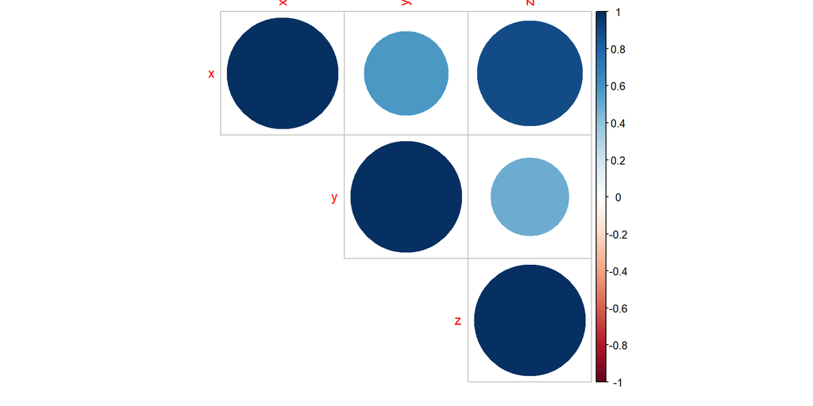

```r
> #install.packages("corrplot")
> library(corrplot)
> corrplot(corr_matrix, type="upper")
```

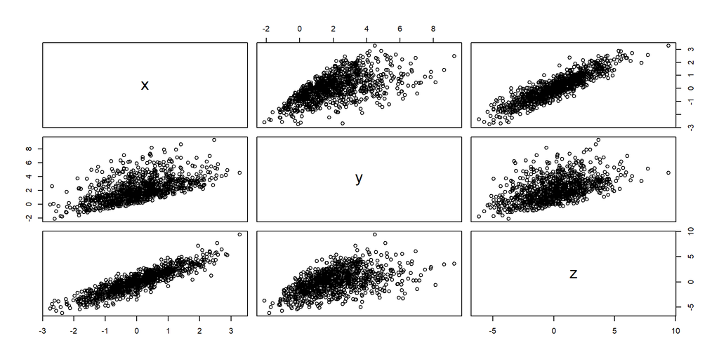

```r
> plot(data)
```

# Partial Correlation

**Partial correlation** is the linear relationship between two variables while controlling for a third variable (or more variables).

- Purpose - find the unique variance between two variables while eliminating the variance from a third variables.

for example:

- Efficacy of a medicine on a disease, with the effect of gender and age removed
- Yield of a crop for different fertilization, with the effect of weather removed

# Partial Correlations Calculations

The case of 3 variables $x$, $y$ and $z$
$$r_{xy,z} = \frac{r_{xy} - r_{xz} r_{yz}}{ \sqrt{1-r_{xz}^2} \sqrt{1 - r_{yz}^2}}$$
This is computationally expensive.

# Other Measures of Centrality

- For a scalar variable, mean or median measures its centrality
- For example: median for a scalar $m$ is a value for which
  $$\Pr(X \ge m) \ge 0.5 \ \text{and} \ \Pr(X \le m) \ge 0.5$$

# Unsupervised Learning

We have a set of features $X_1,X_2,...,X_p$ measured on $n$ observations. At this point, we are not interested in prediction, because we do not have a response variable, $Y$, to predict.

GOAL:

- DISCOVER interesting things about the measurements on $X_1,X_2,...,X_p$.

For example, are there subgroups among the variables or among the observations?

Note: There is no way to check our results here because we do not know the truth so you cannot validate or cross-validate! (hence: unsupervised)

# When can we use Unsupervised Learning techniques?

Consider these situations:

- Cancer researcher - gets data on gene expression levels in 100 patients with breast cancer. The researcher can look for subgroups among the breast cancer samples or among the genes to understand the disease better.
- Online Shopping Site - want to identify groups of shoppers with similar browsing habits, purchase histories and items of interest. Then, individual shoppers can be targeted with ads based on data from shoppers with similar trends.
- Search Engine - similar to online shopping, search engines can choose which results to show based on click histories of individuals with similar search patterns.

Can you think of another one?

# K-means Clustering

**Task**: partition $n$ observations of $p$ features into different groups, such that observations within a group are more similar to each other than to observations in another group

- Within-group similarity: similarity between observations within a group
- Between group similarity: similarity between groups of observations

**What do we accomplish with k-means?** implement the task by balancing within-group similarity and between-group similarity

# K means - How does it work:

https://www.youtube.com/watch?v=mtkWR8sx0NA

Interested in the math behind this and the algorithm used for the code? See page 386-390 of Intro to StatisticaL Learning text

# R Code

```r
> kmeans(x, centers, iter.max = 10, nstart = 1,
+        algorithm = c("Hartigan-Wong", "Lloyd", "Forgy",
+                      "MacQueen"), trace=FALSE)
```

Arguments `x` - numeric matrix of data, or an object that can be coerced to such a matrix (such as a numeric vector or a data frame with all numeric columns).

`centers` -either the number of clusters, say k, or a set of initial (distinct) cluster centres. If a number, a random set of (distinct) rows in x is chosen as the initial centres.

`iter.max` - the maximum number of iterations allowed.

`nstart` - if centers is a number, how many random sets should be chosen?

`algorithm` - character: may be abbreviated. Note that “Lloyd” and “Forgy” are alternative names for one algorithm.

`method` - character: may be abbreviated. “centers” causes fitted to return cluster centers (one for each input point) and “classes” causes fitted to return a vector of class assignments.

`trace` - logical or integer number, currently only used in the default method (“Hartigan-Wong”): if positive (or true), tracing information on the progress of the algorithm is produced. Higher values may produce more tracing information.

# k-means: illustration

Clustering `USArrests` data in `{datasets}`

- Note that all variables here are numeric so you can use them to calculate relationships!

```r
> df<-USArrests
> df<-na.omit(df)  #Removing observations with missing observations
> glimpse(df)
Observations: 50
Variables: 4
$ Murder   <dbl> 13.2, 10.0, 8.1, 8.8, 9.0, 7.9, 3.3, 5.9,...
$ Assault  <int> 236, 263, 294, 190, 276, 204, 110, 238, 3...
$ UrbanPop <int> 58, 48, 80, 50, 91, 78, 77, 72, 80, 60, 8...
$ Rape     <dbl> 21.2, 44.5, 31.0, 19.5, 40.6, 38.7, 11.1,...
```

# K-means: illustration

`kmeans` - want **2 clusters/centers** and choose **25 random starting points** to choose the best starting for the algorithm

- If you leave `nstart` out, it will default to using 1 starting value and choose that as the best one.

```r
> k2 <- kmeans(df, centers = 2, nstart = 25)
```

the result of running kmeans is a list of 9 different elements generated from the kmeans algorithm.

```r
> str(k2)
List of 9
 $ cluster     : Named int [1:50] 1 1 1 1 1 1 2 1 1 1 ...
  ..- attr(*, "names")= chr [1:50] "Alabama" "Alaska" "Arizona" "Arkansas" ...
 $ centers     : num [1:2, 1:4] 11.86 4.84 255 109.76 67.62 ...
  ..- attr(*, "dimnames")=List of 2
  .. ..$ : chr [1:2] "1" "2"
  .. ..$ : chr [1:4] "Murder" "Assault" "UrbanPop" "Rape"
 $ totss       : num 355808
 $ withinss    : num [1:2] 41637 54762
 $ tot.withinss: num 96399
 $ betweenss   : num 259409
 $ size        : int [1:2] 21 29
 $ iter        : int 1
 $ ifault      : int 0
 - attr(*, "class")= chr "kmeans"
```

For the purposes of this class, we are interested in `cluster` which gives the chosen clusters for the dataset. Use `name$cluster` to access the chosen clusters.

# Plotting Clusters

```r
> library(dplyr)
> library(ggplot2)
> #First add the clusters to the dataset using the mutate function and coercing it to a factor instead of numeric
> data= df %>%  mutate(cluster2 = factor(k2$cluster))
```

**Note**: Since we best visualize in 2 dimensions, you will have to look at all the combinations of variables and group by the clusters until you can see which pair of variables gives the best justification for the clusters.

**Note also**: It could be that all pairs can be used to explain the clusters or no pairs can be used to explain the clusters.

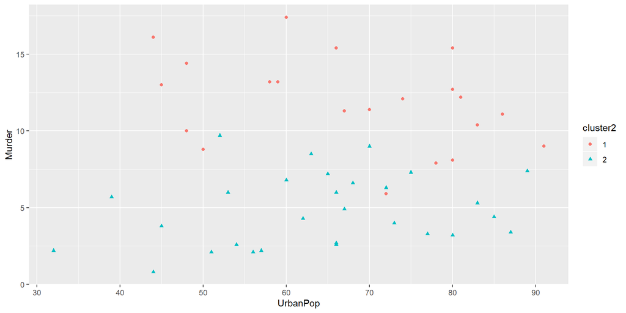

```r
> #Plot
> ggplot(data, aes(x=UrbanPop, y=Murder, color = cluster2, shape=cluster2) )+
+   geom_point()
```

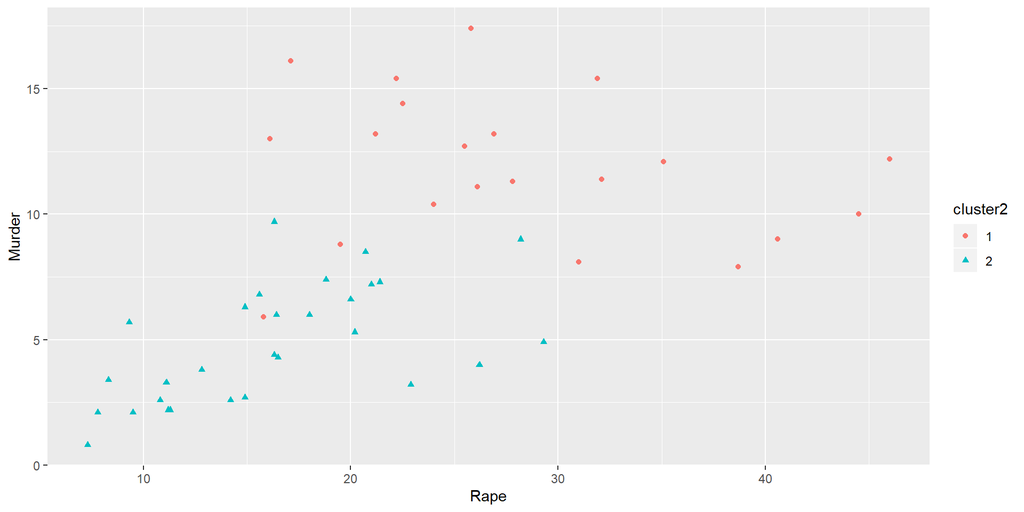

```r
>
> ggplot(data, aes(x=Rape, y=Murder, color = cluster2, shape=cluster2) )+
+   geom_point()
```

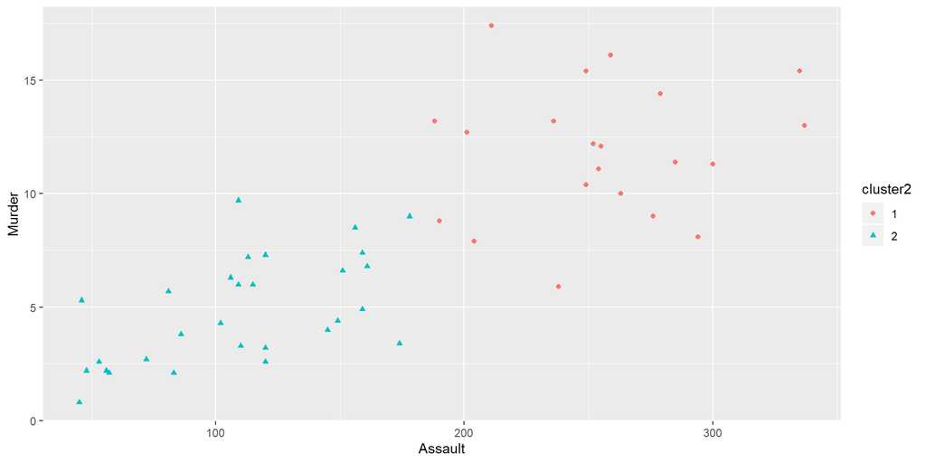

```r
>
> ggplot(data, aes(x=Assault, y=Murder, color = cluster2, shape=cluster2) )+
+   geom_point()
```

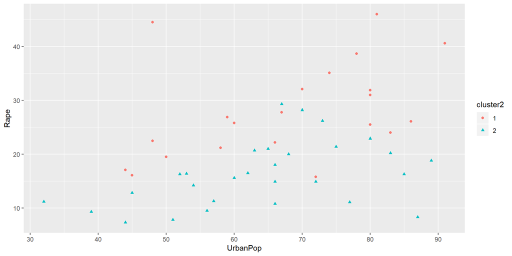

```r
>
> ggplot(data, aes(x=UrbanPop, y=Rape, color = cluster2, shape=cluster2) )+
+   geom_point()
```

# Why use different number of centers?

Because the number of clusters/centers (k) must be set before we start the algorithm, it is often advantageous to use several different values of k and examine the differences in the results.

Let’s execute the same process for 3, 4, and 5 clusters, and see the results. I will only plot UrbanPop versur Murder

```r
> k3 <- kmeans(df, centers = 3, nstart = 25)
> k4 <- kmeans(df, centers = 4, nstart = 25)
> k5 <- kmeans(df, centers = 5, nstart = 25)
```

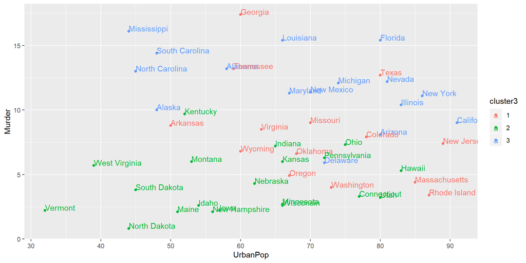

```r
> df3=df %>% mutate(cluster3 = factor(k3$cluster), state = row.names(USArrests))
>
> ggplot(df3, aes(UrbanPop, Murder, color = cluster3, label = state)) + geom_point()+
+   geom_text(hjust=0, vjust=0)   #hjust and vjust positions the labels beside the dot
```

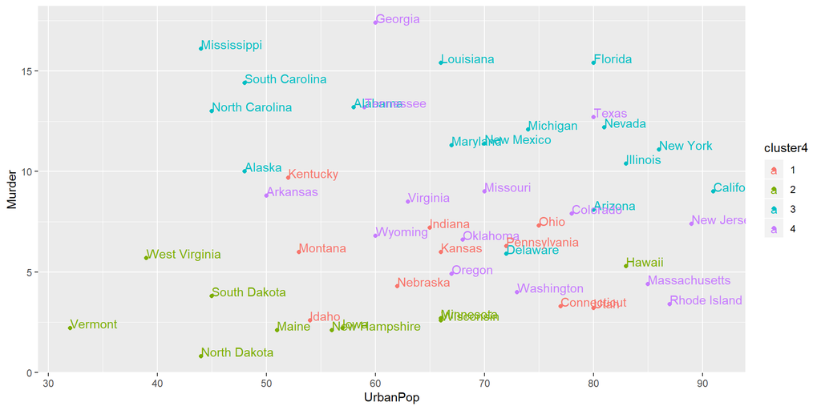

```r
>
> df4=df %>% mutate(cluster4 = factor(k4$cluster), state = row.names(USArrests))
>
> ggplot(df4, aes(UrbanPop, Murder, color = cluster4, label = state)) + geom_point()+
+   geom_text(hjust=0, vjust=0)
```

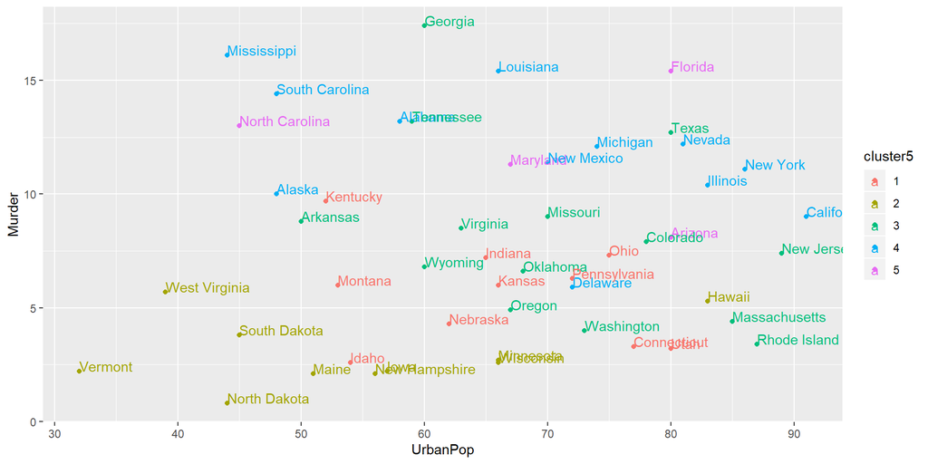

```r
> df5=df %>% mutate(cluster5 = factor(k5$cluster), state = row.names(USArrests))
>
> ggplot(df5, aes(UrbanPop, Murder, color = cluster5, label = state)) + geom_point()+
+   geom_text(hjust=0, vjust=0)
```

# Exercise 1

Generate the following dataset.

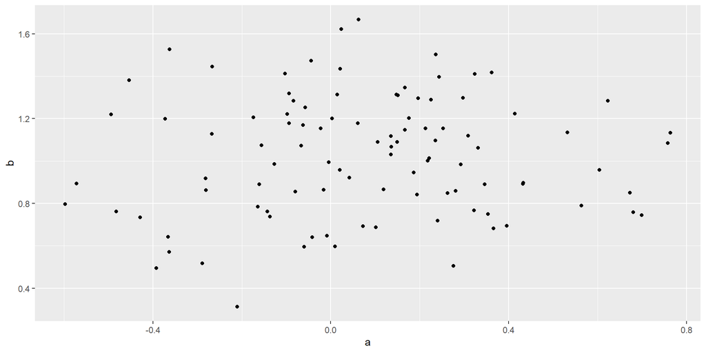

```r
> # a 2-dimensional example
> x <- data.frame(a=rnorm(100, sd = 0.3), b=rnorm(100, mean = 1, sd = 0.3))
> ggplot(x, aes(x=a, y=b))+geom_point()
```

Use this dataset to create 2 clusters and 3 clusters using both x and y variables to create clusters. Plot the clusters.

# Solution Exercise 1

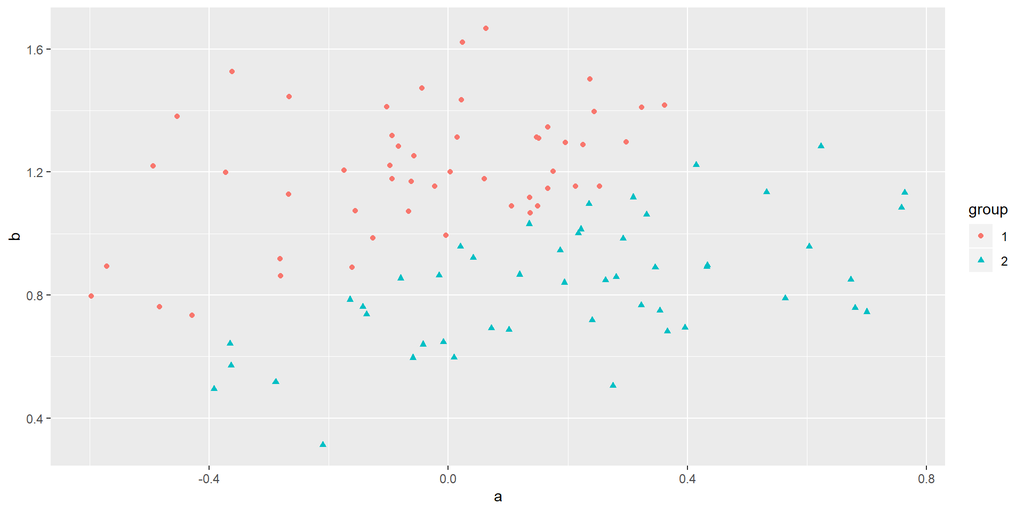

```r
> cl <- kmeans(x, 2)
> x<-x%>%mutate(group=factor(cl$cluster))
> ggplot(x, aes(x=a,y=b, shape= group, color=group))+geom_point()
```

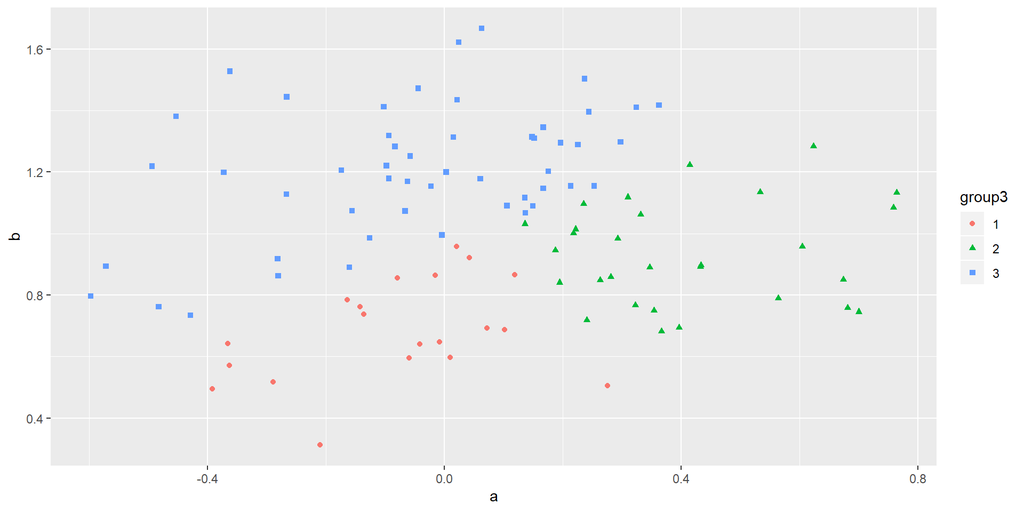

```r
> cl3 <- kmeans(x, 3)
> x<-x%>%mutate(group3=factor(cl3$cluster))
> ggplot(x, aes(x=a,y=b, shape= group3, color=group3))+geom_point()
```

# What do do if you have way too many variables in the dataset?

Notice that more variables require more plots (since you can only plot 2 at a time)

**Suggestion:** Perform PCA (Principal Component Analysis) and use the first 2 Principal components to visualize the clusters.

PCA - process of finding combinations of variables that explain the varaiation in your data. The components are listed in descending order of the amount of variation they explain. So, the first 2 PCA (i.e. the first 2 combinations of variables) will be the combinations that individaually explain more variation than the others.

# Example of Clustering using PCA (Principal Components Analysis)

**Example** using `USarrests` dataset

For 2 clusters:

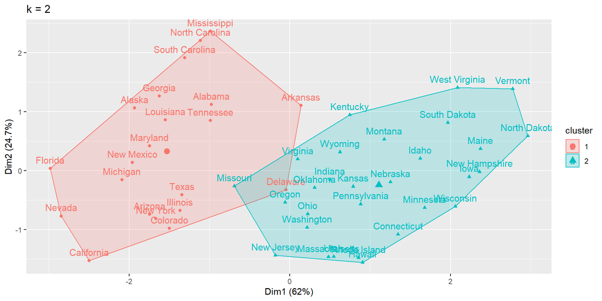

```r
> #install.packages("factoextra")
> library(factoextra)
> fviz_cluster(k2, data = df) + ggtitle("k = 2")
```

If you want just points or just text, specify , `geom = "text"` or `geom="point"` inside `fviz_cluster()`

# Example: How about more clusters

Other clusters:

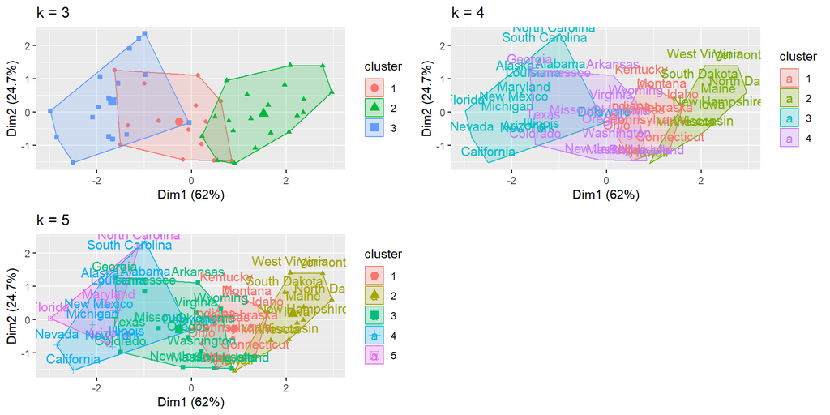

```r
> p2 <- fviz_cluster(k3, geom = "point",  data = df) + ggtitle("k = 3")
> p3 <- fviz_cluster(k4, geom = "text",  data = df) + ggtitle("k = 4")
> p4 <- fviz_cluster(k5,  data = df) + ggtitle("k = 5")
>
> library(gridExtra)
> grid.arrange(p2, p3, p4, nrow = 2)
```

# Hierarchical Clustering

- alternative to k-means that:
  - does not require you to specify the number of clusters
- results in an attractive tree-based representation of clusters (DENDROGRAM)
- height of lines/branches represent distances Can be `"euclidean", "maximum", "manhattan", "canberra", "binary" or "minkowski"`
- AKA bottom-up or algglomeartive clustering

**Result** - Tree diagram that shows relationships betweeen observations

# Algorithm

**Algorithm:** https://vimeo.com/109636143

- Summary:
  - You need to define some type of dissimilarity measure between each pair of observations (eg. euclidean distance - most common)
- `Start` - each observation is its own cluster
- `Next Steps` - the ‘closest’ two observations/clusters will form a cluster
- `Final Step` - This goes on until there is only one cluster with all Observations

# Dendrogram

a tree diagram, especially one showing taxonomic relationships.

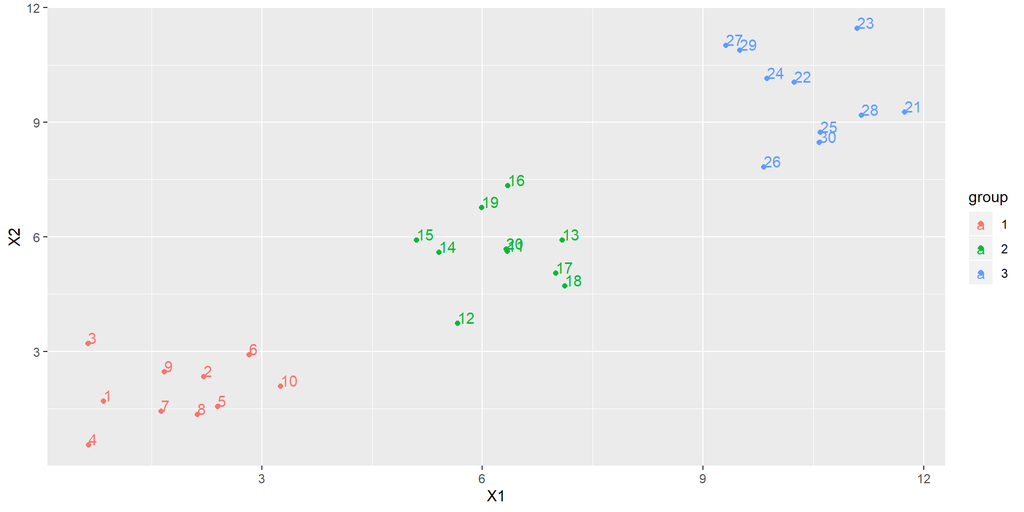

```r
> library(MASS)
> library(ggplot2)
> ##Creating dataframe with predetermined clusters
> a=mvrnorm(n=10, mu=c(2,2), Sigma=diag(2))
> b=mvrnorm(n=10, mu=c(6,6), Sigma=diag(2))
> c=mvrnorm(n=10, mu=c(10,10), Sigma=diag(2))
> d=data.frame(rbind(a,b,c))
>
>
> ## Adding clusters/groups
> d2=d%>%mutate(group=rep(1:3, each=10), group=factor(group), ID = seq(1:30), ID=factor(ID))
>
> ##Plotting to visualize
> ggplot(d2, aes(x=X1, y=X2, color=group, label = ID))+geom_point()+geom_text(hjust=0, vjust=0)
```

# Let’s cluster hierarchically!

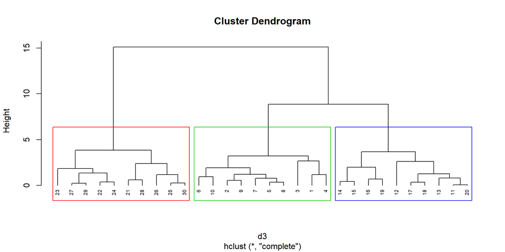

```r
> library(cluster)    # clustering algorithms
> library(factoextra) # clustering visualization
> library(dendextend) # for comparing two dendrograms
>
> # Dissimilarity matrix
> d3 <- dist(d, method = "euclidean")
>
> # Hierarchical clustering using Complete Linkage
> hc1 <- hclust(d3, method = "complete" )
>
> # Plot the obtained dendrogram
> plot(hc1, cex = 0.6, hang = -1)     ##plot dendrogram
> ##draw the cut line (I chose k=3 clusters) and superimpose
> #rectangular compartments for each cluster on the tree . border chooses colors 2:4 (3 colors)
> rect.hclust(hc1 , k = 3, border = 2:4)
```

# Types of Distances for clustering

For 2 points $a=(x_1,y_1)$ and $b=(x_2,y_2)$:

- The *Euclidean distance* or Euclidean metric is the “ordinary” (i.e.straight-line) distance between two points in Euclidean space.
  $$dist_{a,b}= \sqrt{(x_1-x_2)^2+(y_1-y_2)^2}$$
- The *Manhattan distance*, also known as rectilinear distance, city block distance, taxicab metric is defined as the sum of the lengths of the projections of the line segment between the points onto the coordinate axes.

$$dist_{a,b}=\left |x_1-x_2 \right | + \left |y_1-y_2 \right |$$

# Types of Distances - Euclinean versus Manhattan

[figure not shown]

# Types of Linkages

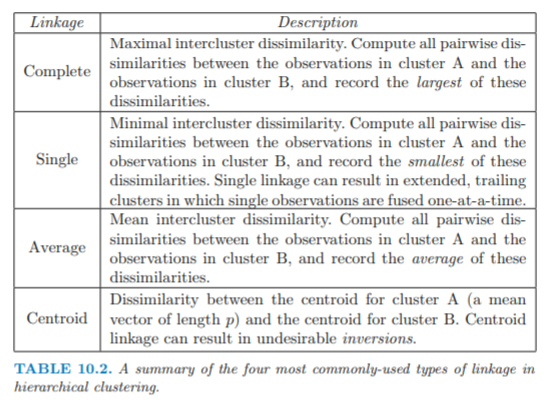

# Cutting Tree/ Dendrogram

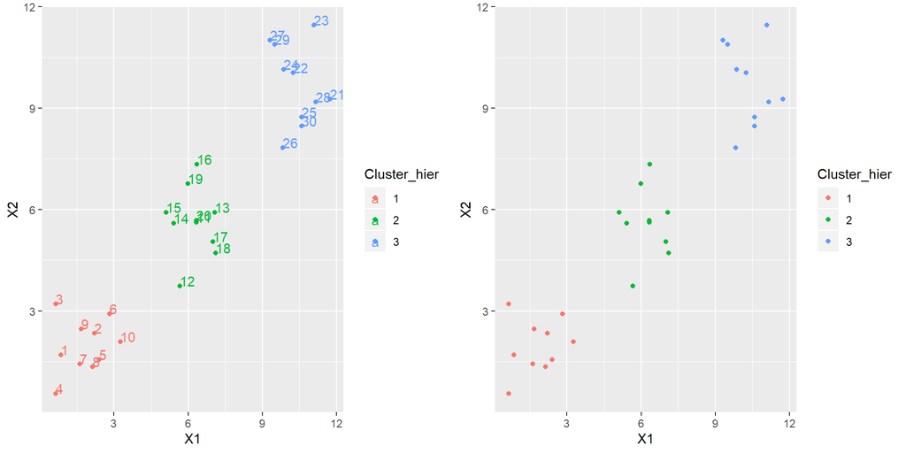

```r
> library(dplyr)
> cut= cutree(hc1, k = 3, h = NULL)  #Deciding where to cut the tree to extract clusters. Here I set k=3 clusters
>
> d4<-d2%>%mutate(Cluster_hier=factor(cut))  #adding the clusters (as a factor instead of numeric) to the original dataset
>
> a=ggplot(d4, aes(x=X1, y = X2, color = Cluster_hier, label = ID)) + geom_point() +geom_text(hjust=0, vjust=0)  #Plotting clusters with labels
> b=ggplot(d4, aes(x=X1, y = X2, color = Cluster_hier)) + geom_point()   #Plotting clusters without labels
> grid.arrange(a,b, nrow = 1)
```

# Exercise

Using the dataset `USArrests`, remove all missing values (if you havent already done so) and cluster hierarchically. Compare clusters formed when you cut the dendrogram at k=3 and k=4

# Solutions

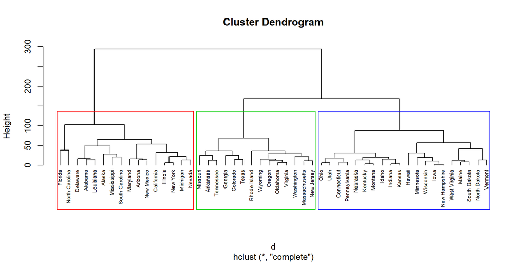

```r
> # Load the data set
> data("USArrests")
>
> # Remove any missing value (i.e, NA values for not available)
> # That might be present in the data
> df <- na.omit(USArrests)
>
> # Dissimilarity matrix
> d <- dist(df, method = "euclidean")
>
> # Hierarchical clustering
> clust <- hclust(d, method = "complete" )
>
> # Plot the obtained dendrogram with k=3
> plot(clust, cex = 0.6, hang = -1)
> ##draw the cut line (I chose k=3 clusters) and superimpose rectangular compartments for each cluster
> ##on the tree. border chooses colors 2:4 (3 colors)
> rect.hclust(clust , k = 3, border = 2:4)
```

# Solutions

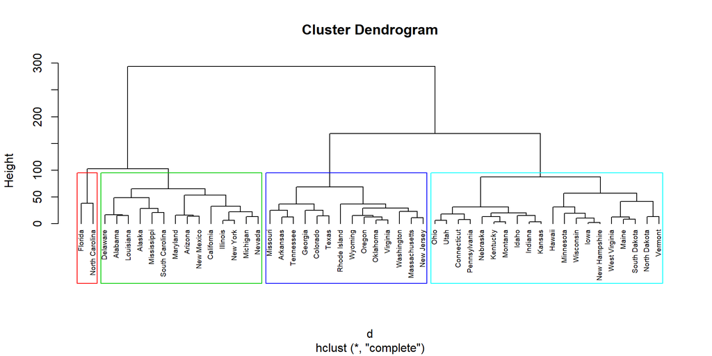

```r
> # Plot the obtained dendrogram with k=4
> plot(clust, cex = 0.6, hang = -1)
> ##draw the cut line (I chose k=3 clusters) and superimpose
> #rectangular compartments for each cluster on the tree . border chooses colors 2:5 (4 colors)
> rect.hclust(clust , k = 4, border = 2:5)
```

# Standardization - Why should we do it?

New Step - As we don’t want the hierarchical clustering result to depend to an arbitrary variable unit, we start by scaling the data using the R function scale()

**What does scaling do?** - the DATA must be standardized (i.e., scaled) to make them comparable. Recall that, standardization consists of transforming the variables such that they have mean zero and standard deviation one. You can read more about standardization in the following article: https://www.datanovia.com/en/lessons/clustering-distance-measures/

# Standardization - Why should we do it?

Notice a difference?

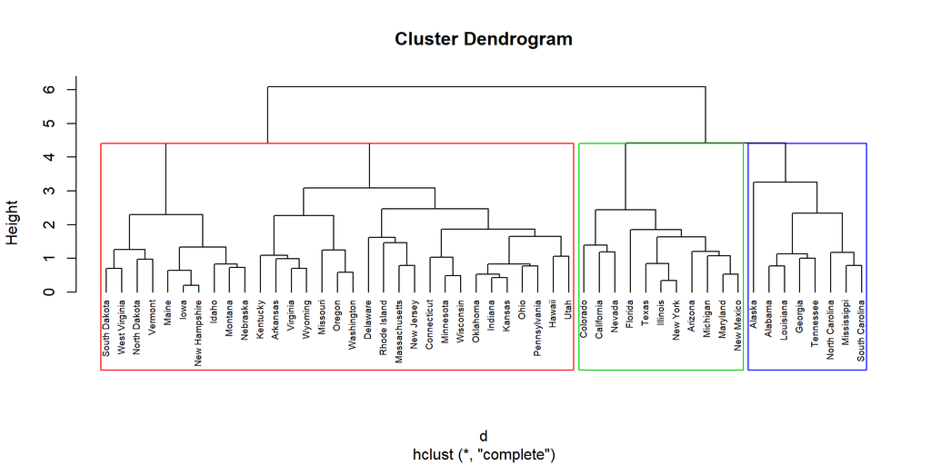

```r
> # Load the data set
> data("USArrests")
>
> # Remove any missing value (i.e, NA values for not available)
> # That might be present in the data
> df <- na.omit(USArrests)
>
> #SCALING DATA
> df <- scale(df)
> head(df)
               Murder   Assault   UrbanPop         Rape
Alabama    1.24256408 0.7828393 -0.5209066 -0.003416473
Alaska     0.50786248 1.1068225 -1.2117642  2.484202941
Arizona    0.07163341 1.4788032  0.9989801  1.042878388
Arkansas   0.23234938 0.2308680 -1.0735927 -0.184916602
California 0.27826823 1.2628144  1.7589234  2.067820292
Colorado   0.02571456 0.3988593  0.8608085  1.864967207
>
> # Dissimilarity matrix
> d <- dist(df, method = "euclidean")
>
> # Hierarchical clustering
> clust <- hclust(d, method="complete")
>
> # Plot the obtained dendrogram with k=3
> plot(clust, cex = 0.6, hang = -1)
> ##draw the cut line (I chose k=3 clusters) and superimpose
> #rectangular compartments for each cluster on the tree . border chooses colors 2:4 (3 colors)
>
> rect.hclust(clust , k = 3, border = 2:4)
```